# Análisis Bases de dato Laboratorio C. citri

Madeleyne Parra Fuente

25/3/2021

## 1. Librerías

```r
#libraries----
library(dplyr)
```

```r
library(ggplot2)
library(agricolae)
library(officer)
library(rvg)
```

# 2. Lectura de los datos

Se realiza la lectura de los datos

```r
#Readin Data base----
#Field data base
db_D_citri_lab<- read.csv2("./Data/BD Dinámica Poblacional -D. citri Caribia_Laboratorio_Actualizada_21-12-2020 (1).csv", encoding = "UTF-8")
db_D_citri_lab<- db_D_citri_lab[-c(8833:nrow(db_D_citri_lab))]
```

# 3. Limpieza de los datos

```r
#NIFAS column is created
db_D_citri_lab$NINFAS<- db_D_citri_lab$NINFA.1+ db_D_citri_lab$NINFA.2+db_D_citri_lab$NINFA.3+db_D_citri_lab$NINFA.4+db_D_citri_lab$NINFA.5
#No important columns are deleted
db_D_citri_lab<- db_D_citri_lab[c("MES", "CULTIVO", "COPA", "PATRÓN", "PUNTO",
                                       "HUEVOS", "NINFAS", "ADULTO")]
#Set factors
#11 levels in "MES" factor. 4th month is not present
db_D_citri_lab$MES<- as.factor(db_D_citri_lab$MES)
#3 levels: Naranja mandarina y limón
db_D_citri_lab$CULTIVO<- as.factor(db_D_citri_lab$CULTIVO)
#16 varieties
db_D_citri_lab$COPA<- as.factor(db_D_citri_lab$COPA)
#2 Rootstocks
db_D_citri_lab$PATRÓN<- as.factor(db_D_citri_lab$PATRÓN)
#4 Cardinal points
db_D_citri_lab$PUNTO<- as.factor(db_D_citri_lab$PUNTO)
```

## 4. Estadísiticos descriptivos huevos

```r
#Descriptive statistics----
#Observations and distribution
summary(db_D_citri_lab)
```

```
##       MES            CULTIVO                 COPA       PATRÓN
##  1      :1152   LIMON    :1728   Arrayana      : 576   CPB :4608
##  9      :1152   MANDARINA:2304   Eureka        : 576   SxE :4608
##  12     :1152   NARANJA  :5184   Fairchild     : 576   NA's: 384
##  2      : 768   NA's     : 384   Frost Valencia: 576
##  5      : 768                    Hamlin        : 576
##  (Other):4224                    (Other)       :6336
##  NA's   : 384                    NA's          : 384
##     PUNTO          HUEVOS          NINFAS            ADULTO
##  Este  :1824   Min.   :  0.0   Min.   :  0.000   Min.   : 0.000
##  Este  : 480   1st Qu.:  0.0   1st Qu.:  0.000   1st Qu.: 0.000
##  Norte :2304   Median :  0.0   Median :  1.000   Median : 0.000
##  Oeste :1824   Mean   :  8.6   Mean   :  5.992   Mean   : 0.086
##  Oeste : 480   3rd Qu.:  6.0   3rd Qu.:  6.000   3rd Qu.: 0.000
##  Sur   :2304   Max.   :457.0   Max.   :266.000   Max.   :11.000
##  NA's  : 384   NA's   :7365    NA's   :7365      NA's   :7366
```

```r
#summary statistics byb factors
#MES
with(db_D_citri_lab, tapply(HUEVOS, MES, function(x) {
  sprintf("M (SD) = %1.2f (%1.2f)", mean(x), sd(x))
}))
```

```
##                  1                  2                  3                  5
## "M (SD) = NA (NA)" "M (SD) = NA (NA)" "M (SD) = NA (NA)" "M (SD) = NA (NA)"
##                  6                  7                  8                  9
## "M (SD) = NA (NA)" "M (SD) = NA (NA)" "M (SD) = NA (NA)" "M (SD) = NA (NA)"
##                 10                 11                 12
## "M (SD) = NA (NA)" "M (SD) = NA (NA)" "M (SD) = NA (NA)"
```

```r
#CULTIVO
with(db_D_citri_lab, tapply(HUEVOS, CULTIVO, function(x) {
  sprintf("M (SD) = %1.2f (%1.2f)", mean(x), sd(x))
}))
```

```
##              LIMON          MANDARINA            NARANJA
## "M (SD) = NA (NA)" "M (SD) = NA (NA)" "M (SD) = NA (NA)"
```

```r
#COPA
with(db_D_citri_lab, tapply(HUEVOS, COPA, function(x) {
  sprintf("M (SD) = %1.2f (%1.2f)", mean(x), sd(x))
}))
```

```
##           Arrayana             Eureka          Fairchild     Frost Valencia
## "M (SD) = NA (NA)" "M (SD) = NA (NA)" "M (SD) = NA (NA)" "M (SD) = NA (NA)"
##    Garcia Valencia    García Valencia             Hamlin          Lannelate
## "M (SD) = NA (NA)" "M (SD) = NA (NA)" "M (SD) = NA (NA)" "M (SD) = NA (NA)"
##              Oneco      Owari Satsuma           Pajarito           Pajárito
## "M (SD) = NA (NA)" "M (SD) = NA (NA)" "M (SD) = NA (NA)" "M (SD) = NA (NA)"
##       Parson Brown       Pera del Río            Perrine          Pinneaple
## "M (SD) = NA (NA)" "M (SD) = NA (NA)" "M (SD) = NA (NA)" "M (SD) = NA (NA)"
##         Pinneapple      Sweety orange      Sweety Orange         Washington
## "M (SD) = NA (NA)" "M (SD) = NA (NA)" "M (SD) = NA (NA)" "M (SD) = NA (NA)"
```

```r
#PATRÓN
with(db_D_citri_lab, tapply(HUEVOS, PATRÓN, function(x) {
  sprintf("M (SD) = %1.2f (%1.2f)", mean(x), sd(x))
}))
```

```
##                CPB                SxE
## "M (SD) = NA (NA)" "M (SD) = NA (NA)"
```

```r
#PUNTO
with(db_D_citri_lab, tapply(HUEVOS, PUNTO, function(x) {
  sprintf("M (SD) = %1.2f (%1.2f)", mean(x), sd(x))
  }))
```

```
##               Este              Este               Norte              Oeste
## "M (SD) = NA (NA)" "M (SD) = NA (NA)" "M (SD) = NA (NA)" "M (SD) = NA (NA)"
##             Oeste                 Sur
## "M (SD) = NA (NA)" "M (SD) = NA (NA)"
```

## 5. Estadísiticos descriptivos NINFAS

```r
#Descriptive statistics----
#Observations and distribution
summary(db_D_citri_lab)
```

```
##       MES            CULTIVO                 COPA       PATRÓN
##  1      :1152   LIMON    :1728   Arrayana      : 576   CPB :4608
##  9      :1152   MANDARINA:2304   Eureka        : 576   SxE :4608
##  12     :1152   NARANJA  :5184   Fairchild     : 576   NA's: 384
##  2      : 768   NA's     : 384   Frost Valencia: 576
##  5      : 768                    Hamlin        : 576
##  (Other):4224                    (Other)       :6336
##  NA's   : 384                    NA's          : 384
##     PUNTO          HUEVOS          NINFAS            ADULTO
##  Este  :1824   Min.   :  0.0   Min.   :  0.000   Min.   : 0.000
##  Este  : 480   1st Qu.:  0.0   1st Qu.:  0.000   1st Qu.: 0.000
##  Norte :2304   Median :  0.0   Median :  1.000   Median : 0.000
##  Oeste :1824   Mean   :  8.6   Mean   :  5.992   Mean   : 0.086
##  Oeste : 480   3rd Qu.:  6.0   3rd Qu.:  6.000   3rd Qu.: 0.000
##  Sur   :2304   Max.   :457.0   Max.   :266.000   Max.   :11.000
##  NA's  : 384   NA's   :7365    NA's   :7365      NA's   :7366
```

```r
#summary statistics byb factors
#MES
with(db_D_citri_lab, tapply(NINFAS, MES, function(x) {
  sprintf("M (SD) = %1.2f (%1.2f)", mean(x), sd(x))
}))
```

```
##                  1                  2                  3                  5
## "M (SD) = NA (NA)" "M (SD) = NA (NA)" "M (SD) = NA (NA)" "M (SD) = NA (NA)"
##                  6                  7                  8                  9
## "M (SD) = NA (NA)" "M (SD) = NA (NA)" "M (SD) = NA (NA)" "M (SD) = NA (NA)"
##                 10                 11                 12
## "M (SD) = NA (NA)" "M (SD) = NA (NA)" "M (SD) = NA (NA)"
```

```r
#CULTIVO
with(db_D_citri_lab, tapply(NINFAS, CULTIVO, function(x) {
  sprintf("M (SD) = %1.2f (%1.2f)", mean(x), sd(x))
}))
```

```
##              LIMON          MANDARINA            NARANJA
## "M (SD) = NA (NA)" "M (SD) = NA (NA)" "M (SD) = NA (NA)"
```

```r
#COPA
with(db_D_citri_lab, tapply(NINFAS, COPA, function(x) {
  sprintf("M (SD) = %1.2f (%1.2f)", mean(x), sd(x))
}))
```

```
##           Arrayana             Eureka          Fairchild     Frost Valencia
## "M (SD) = NA (NA)" "M (SD) = NA (NA)" "M (SD) = NA (NA)" "M (SD) = NA (NA)"
##    Garcia Valencia    García Valencia             Hamlin          Lannelate
## "M (SD) = NA (NA)" "M (SD) = NA (NA)" "M (SD) = NA (NA)" "M (SD) = NA (NA)"
##              Oneco      Owari Satsuma           Pajarito           Pajárito
## "M (SD) = NA (NA)" "M (SD) = NA (NA)" "M (SD) = NA (NA)" "M (SD) = NA (NA)"
##       Parson Brown       Pera del Río            Perrine          Pinneaple
## "M (SD) = NA (NA)" "M (SD) = NA (NA)" "M (SD) = NA (NA)" "M (SD) = NA (NA)"
##         Pinneapple      Sweety orange      Sweety Orange         Washington
## "M (SD) = NA (NA)" "M (SD) = NA (NA)" "M (SD) = NA (NA)" "M (SD) = NA (NA)"
```

```r
#PATRÓN
with(db_D_citri_lab, tapply(NINFAS, PATRÓN, function(x) {
  sprintf("M (SD) = %1.2f (%1.2f)", mean(x), sd(x))
}))
```

```
##                CPB                SxE
## "M (SD) = NA (NA)" "M (SD) = NA (NA)"
```

```r
#PUNTO
with(db_D_citri_lab, tapply(NINFAS, PUNTO, function(x) {
  sprintf("M (SD) = %1.2f (%1.2f)", mean(x), sd(x))
}))
```

```
##               Este              Este               Norte              Oeste
## "M (SD) = NA (NA)" "M (SD) = NA (NA)" "M (SD) = NA (NA)" "M (SD) = NA (NA)"
##             Oeste                 Sur
## "M (SD) = NA (NA)" "M (SD) = NA (NA)"
```

## 6. Estadísiticos descriptivos ADULTOS

```r
#Descriptive statistics----
#Observations and distribution
summary(db_D_citri_lab)
```

```
##       MES            CULTIVO                 COPA       PATRÓN
##  1      :1152   LIMON    :1728   Arrayana      : 576   CPB :4608
##  9      :1152   MANDARINA:2304   Eureka        : 576   SxE :4608
##  12     :1152   NARANJA  :5184   Fairchild     : 576   NA's: 384
##  2      : 768   NA's     : 384   Frost Valencia: 576
##  5      : 768                    Hamlin        : 576
##  (Other):4224                    (Other)       :6336
##  NA's   : 384                    NA's          : 384
##     PUNTO          HUEVOS          NINFAS            ADULTO
##  Este  :1824   Min.   :  0.0   Min.   :  0.000   Min.   : 0.000
##  Este  : 480   1st Qu.:  0.0   1st Qu.:  0.000   1st Qu.: 0.000
##  Norte :2304   Median :  0.0   Median :  1.000   Median : 0.000
##  Oeste :1824   Mean   :  8.6   Mean   :  5.992   Mean   : 0.086
##  Oeste : 480   3rd Qu.:  6.0   3rd Qu.:  6.000   3rd Qu.: 0.000
##  Sur   :2304   Max.   :457.0   Max.   :266.000   Max.   :11.000
##  NA's  : 384   NA's   :7365    NA's   :7365      NA's   :7366
```

```r
#summary statistics byb factors
#MES
with(db_D_citri_lab, tapply(ADULTO, MES, function(x) {
  sprintf("M (SD) = %1.2f (%1.2f)", mean(x), sd(x))
}))
```

```
##                  1                  2                  3                  5
## "M (SD) = NA (NA)" "M (SD) = NA (NA)" "M (SD) = NA (NA)" "M (SD) = NA (NA)"
##                  6                  7                  8                  9
## "M (SD) = NA (NA)" "M (SD) = NA (NA)" "M (SD) = NA (NA)" "M (SD) = NA (NA)"
##                 10                 11                 12
## "M (SD) = NA (NA)" "M (SD) = NA (NA)" "M (SD) = NA (NA)"
```

```r
#CULTIVO
with(db_D_citri_lab, tapply(ADULTO, CULTIVO, function(x) {
  sprintf("M (SD) = %1.2f (%1.2f)", mean(x), sd(x))
}))
```

```
##              LIMON          MANDARINA            NARANJA
## "M (SD) = NA (NA)" "M (SD) = NA (NA)" "M (SD) = NA (NA)"
```

```r
#COPA
with(db_D_citri_lab, tapply(ADULTO, COPA, function(x) {
  sprintf("M (SD) = %1.2f (%1.2f)", mean(x), sd(x))
}))
```

```
##           Arrayana             Eureka          Fairchild     Frost Valencia
## "M (SD) = NA (NA)" "M (SD) = NA (NA)" "M (SD) = NA (NA)" "M (SD) = NA (NA)"
##    Garcia Valencia    García Valencia             Hamlin          Lannelate
## "M (SD) = NA (NA)" "M (SD) = NA (NA)" "M (SD) = NA (NA)" "M (SD) = NA (NA)"
##              Oneco      Owari Satsuma           Pajarito           Pajárito
## "M (SD) = NA (NA)" "M (SD) = NA (NA)" "M (SD) = NA (NA)" "M (SD) = NA (NA)"
##       Parson Brown       Pera del Río            Perrine          Pinneaple
## "M (SD) = NA (NA)" "M (SD) = NA (NA)" "M (SD) = NA (NA)" "M (SD) = NA (NA)"
##         Pinneapple      Sweety orange      Sweety Orange         Washington
## "M (SD) = NA (NA)" "M (SD) = NA (NA)" "M (SD) = NA (NA)" "M (SD) = NA (NA)"
```

```r
#PATRÓN
with(db_D_citri_lab, tapply(ADULTO, PATRÓN, function(x) {
  sprintf("M (SD) = %1.2f (%1.2f)", mean(x), sd(x))
}))
```

```
##                CPB                SxE
## "M (SD) = NA (NA)" "M (SD) = NA (NA)"
```

```r
#PUNTO
with(db_D_citri_lab, tapply(ADULTO, PUNTO, function(x) {
  sprintf("M (SD) = %1.2f (%1.2f)", mean(x), sd(x))
}))
```

```
##               Este              Este               Norte              Oeste
## "M (SD) = NA (NA)" "M (SD) = NA (NA)" "M (SD) = NA (NA)" "M (SD) = NA (NA)"
##             Oeste                 Sur
## "M (SD) = NA (NA)" "M (SD) = NA (NA)"
```

## 7. Prueba no paramétrica

### Kruskal Wallis para la variable huevos en el factor MES

Se realiza el estadístico con todos los meses ya que estos si presentan la misma distribución. Es de resaltar que con esta distribución los datos pueden ajustarse a un modelo Poisson o binomial negativo

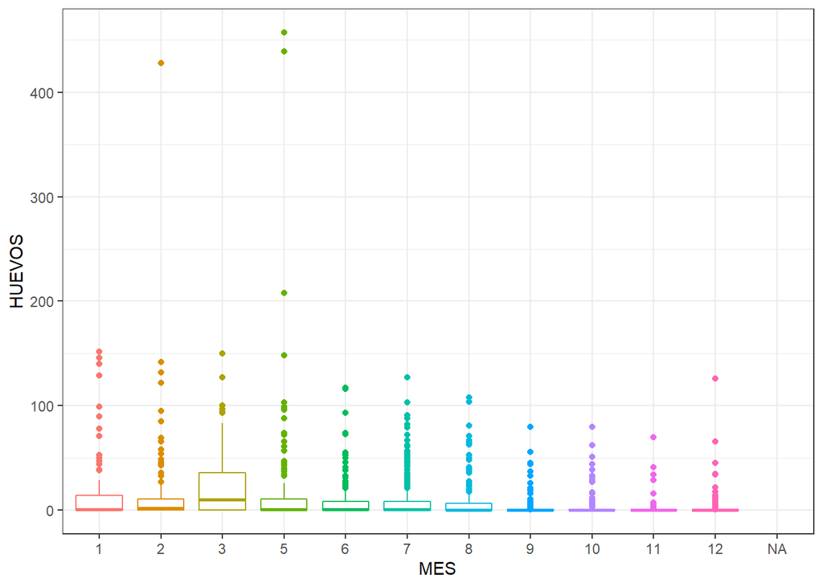

```r
#Non-parametric approach----
#Boxplot MES
ggplot(data = db_D_citri_lab, mapping = aes(x = MES, y = HUEVOS, colour = MES)) +
  geom_boxplot() +
  theme_bw() +
  theme(legend.position = "none")
```

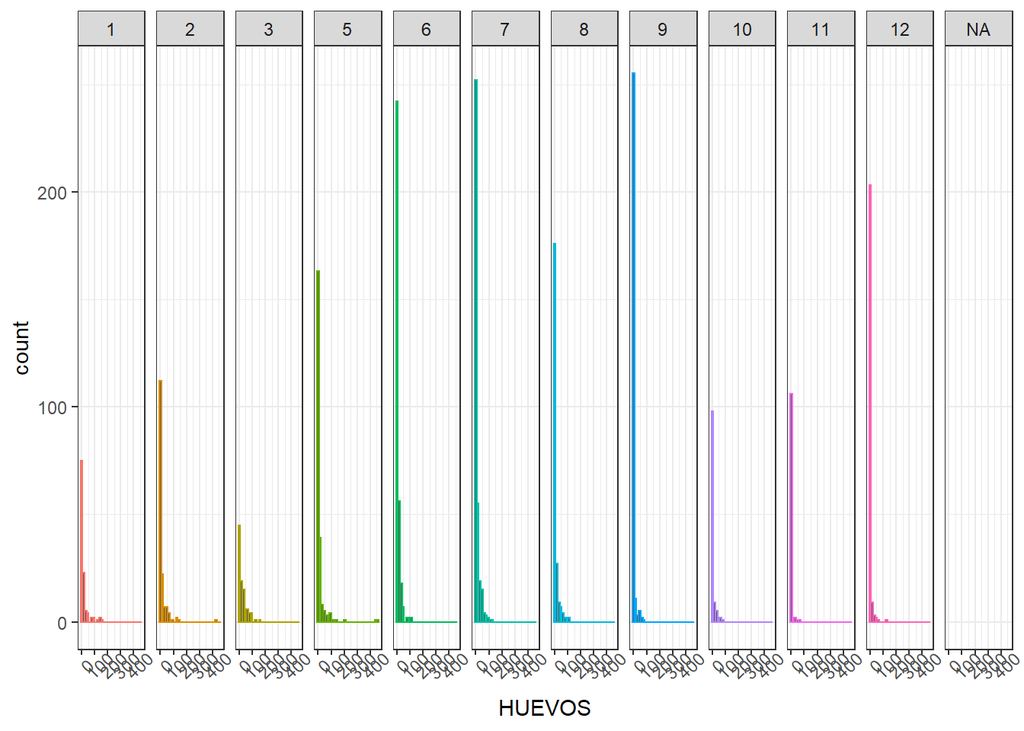

```r
#Distribution MES
ggplot(data = db_D_citri_lab, mapping = aes(x = HUEVOS, colour = MES)) +
  geom_histogram() +
  theme_bw() +
  facet_grid(. ~ MES) +
  theme(legend.position = "none")+
  theme(axis.text.x = element_text(angle = 45))
```

```r
#KW test group_1
group_1_month<- kruskal(db_D_citri_lab$HUEVOS, db_D_citri_lab$MES,group=TRUE, p.adj = "bonferroni")
group_1_month
```

```
## $statistics
##      Chisq Df p.chisq
##   268.6012 10       0
##
## $parameters
##             test  p.ajusted             name.t ntr alpha
##   Kruskal-Wallis bonferroni db_D_citri_lab$MES  11  0.05
##
## $means
##    db_D_citri_lab.HUEVOS      rank       std   r Min Max Q25 Q50   Q75
## 1              14.504348 1263.9565 30.577877 115   0 152   0   1 14.00
## 10              5.145299  953.5684 13.822935 117   0  80   0   0  1.00
## 11              2.009009  786.0541  8.813724 111   0  70   0   0  0.00
## 12              2.630137  846.4110 11.380621 219   0 126   0   0  0.00
## 2              14.348101 1275.8956 41.007833 158   0 428   0   2 10.75
## 3              23.495050 1532.8168 31.165245 101   0 150   0  10 36.00
## 5              14.591304 1246.8500 47.661451 230   0 457   0   1 11.00
## 6               7.536585 1253.6143 15.112378 328   0 117   0   1  8.25
## 7               9.136364 1221.3835 17.936534 352   0 127   0   1  8.25
## 8               7.497797 1100.6498 17.338477 227   0 108   0   0  6.50
## 9               2.761733  848.5560  9.800598 277   0  80   0   0  0.00
##
## $comparison
## NULL
##
## $groups
##    db_D_citri_lab$HUEVOS groups
## 3              1532.8168      a
## 2              1275.8956      b
## 1              1263.9565      b
## 6              1253.6143      b
## 5              1246.8500      b
## 7              1221.3835      b
## 8              1100.6498     bc
## 10              953.5684     cd
## 9               848.5560      d
## 12              846.4110      d
## 11              786.0541      d
##
## attr(,"class")
## [1] "group"
```

### Kruskal Wallis para la variable huevos en el factor CULTIVO

Se realiza el estadístico con todos los CULTIVARES ya que estos si presentan la misma distribución. Es de resaltar que con esta distribución los datos pueden ajustarse a un modelo Poisson o binomial negativo

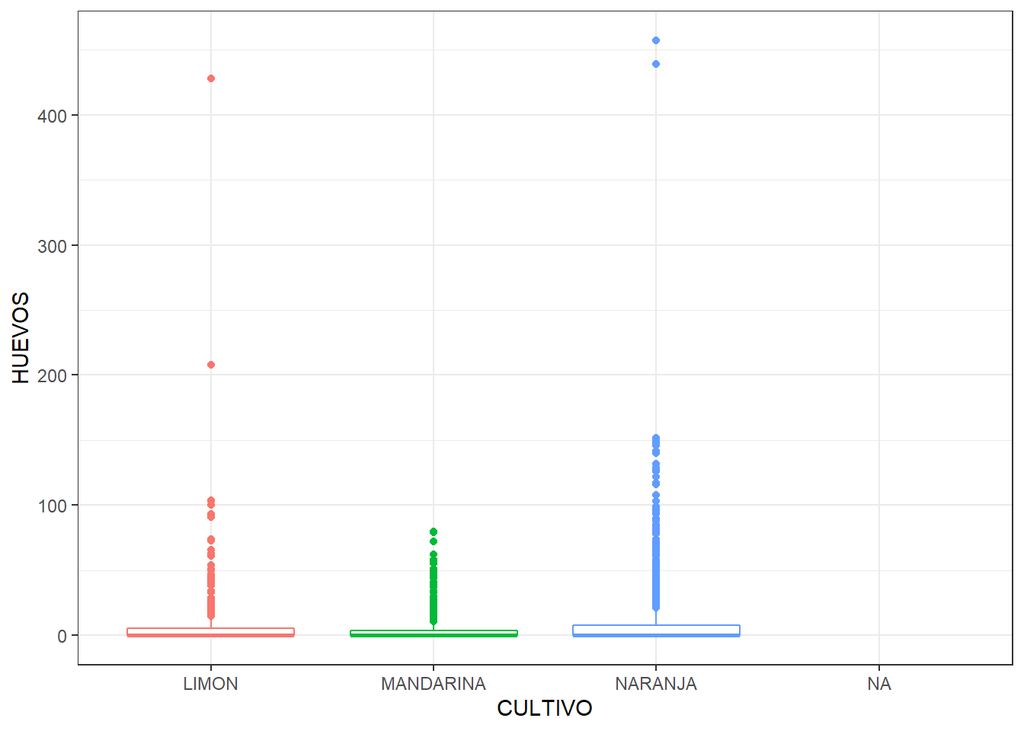

```r
#Non-parametric approach----
#Boxplot CULTIVO
ggplot(data = db_D_citri_lab, mapping = aes(x = CULTIVO, y = HUEVOS, colour = CULTIVO)) +
  geom_boxplot() +
  theme_bw() +
  theme(legend.position = "none")
```

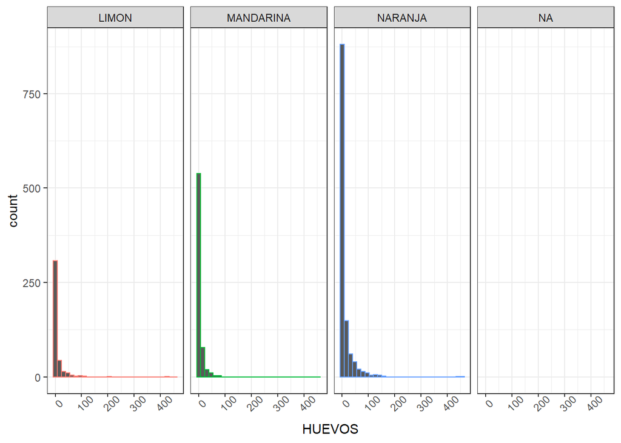

```r
#Distribution CULTIVO
ggplot(data = db_D_citri_lab, mapping = aes(x = HUEVOS, colour = CULTIVO)) +
  geom_histogram() +
  theme_bw() +
  facet_grid(. ~ CULTIVO) +
  theme(legend.position = "none")+
  theme(axis.text.x = element_text(angle = 45))
```

```r
#KW test group_1
group_1_month<- kruskal(db_D_citri_lab$HUEVOS, db_D_citri_lab$CULTIVO,group=TRUE, p.adj = "bonferroni")
group_1_month
```

```
## $statistics
##      Chisq Df     p.chisq
##   13.71346  2 0.001052351
##
## $parameters
##             test  p.ajusted                 name.t ntr alpha
##   Kruskal-Wallis bonferroni db_D_citri_lab$CULTIVO   3  0.05
##
## $means
##           db_D_citri_lab.HUEVOS     rank      std    r Min Max Q25 Q50  Q75
## LIMON                  8.607692 1098.737 28.75403  390   0 428   0   0 5.75
## MANDARINA              4.446319 1056.209 10.42471  652   0  80   0   0 4.00
## NARANJA               10.866723 1158.067 28.72126 1193   0 457   0   0 8.00
##
## $comparison
## NULL
##
## $groups
##           db_D_citri_lab$HUEVOS groups
## NARANJA                1158.067      a
## LIMON                  1098.737     ab
## MANDARINA              1056.209      b
##
## attr(,"class")
## [1] "group"
```

### Kruskal Wallis para la variable huevos en el factor COPA

Se realiza el estadístico con todos lAS VARIEDADES ya que estos si presentan la misma distribución. Es de resaltar que con esta distribución los datos pueden ajustarse a un modelo Poisson o binomial negativo

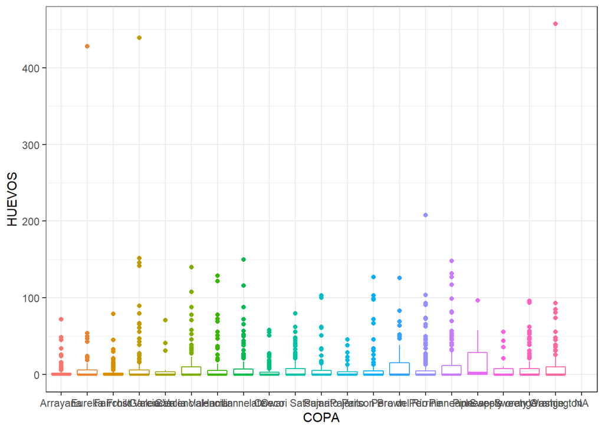

```r
#Non-parametric approach----
#Boxplot COPA
ggplot(data = db_D_citri_lab, mapping = aes(x = COPA, y = HUEVOS, colour = COPA)) +
  geom_boxplot() +
  theme_bw() +
  theme(legend.position = "none")
```

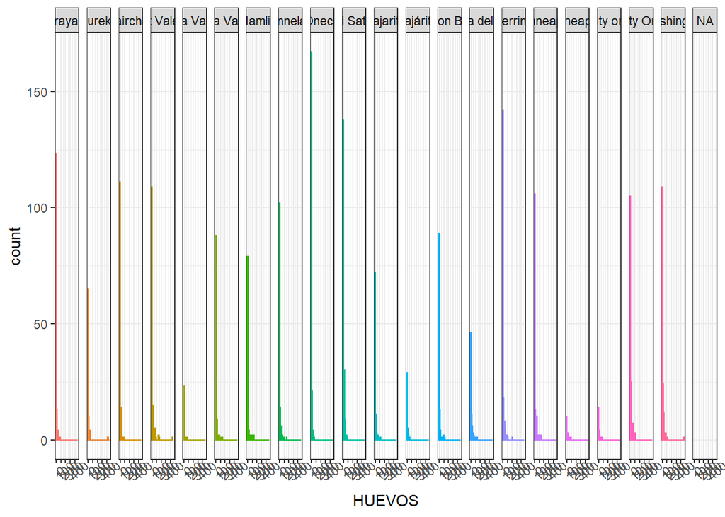

```r
#Distribution COPA
ggplot(data = db_D_citri_lab, mapping = aes(x = HUEVOS, colour = COPA)) +
  geom_histogram() +
  theme_bw() +
  facet_grid(. ~ COPA) +
  theme(legend.position = "none")+
  theme(axis.text.x = element_text(angle = 45))
```

```r
#KW test group_1
group_1_month<- kruskal(db_D_citri_lab$HUEVOS, db_D_citri_lab$COPA,group=TRUE, p.adj = "bonferroni")
group_1_month
```

```
## $statistics
##      Chisq Df    p.chisq
##   35.55148 19 0.01197625
##
## $parameters
##             test  p.ajusted              name.t ntr alpha
##   Kruskal-Wallis bonferroni db_D_citri_lab$COPA  20  0.05
##
## $means
##                 db_D_citri_lab.HUEVOS      rank       std   r Min Max Q25 Q50
## Arrayana                     3.566434  994.6923  9.527987 143   0  72   0 0.0
## Eureka                      10.382716 1080.2160 48.322502  81   0 428   0 0.0
## Fairchild                    3.527132  994.2248  9.667986 129   0  79   0 0.0
## Frost Valencia              13.636364 1162.8287 44.323641 143   0 439   0 0.0
## Garcia Valencia              6.461538 1035.3269 16.385923  26   0  71   0 0.0
## García Valencia             10.442623 1200.4344 22.105700 122   0 140   0 0.0
## Hamlin                       9.343137 1080.0686 23.037849 102   0 129   0 0.0
## Lannelate                    9.401515 1129.5909 22.299098 132   0 150   0 0.0
## Oneco                        3.533333 1023.4564  8.454406 195   0  58   0 0.0
## Owari Satsuma                6.729730 1181.5027 12.912432 185   0  80   0 0.0
## Pajarito                     7.340659 1099.7692 18.531187  91   0 103   0 0.0
## Pajárito                     5.675676 1017.1757 11.535101  37   0  46   0 0.0
## Parson Brown                 8.707965 1119.3584 22.382104 113   0 127   0 0.0
## Pera del Río                12.442857 1247.0000 23.217707  70   0 126   0 0.5
## Perrine                      9.049724 1123.1796 23.376930 181   0 208   0 0.0
## Pinneaple                   13.068966 1155.5793 27.570026 145   0 148   0 0.0
## Pinneapple                  18.833333 1334.5278 27.418864  18   0  97   0 2.5
## Sweety orange                9.333333 1182.3333 16.282915  21   0  56   0 0.0
## Sweety Orange                8.959184 1180.1259 18.351917 147   0  96   0 0.0
## Washington                  11.532468 1162.2078 39.965863 154   0 457   0 0.0
##                   Q75
## Arrayana         2.00
## Eureka           6.00
## Fairchild        2.00
## Frost Valencia   6.00
## Garcia Valencia  3.75
## García Valencia 10.00
## Hamlin           5.75
## Lannelate        7.00
## Oneco            3.00
```

[output cut: 25 more lines]

```
## Pinneaple                   1155.5793      a
## Lannelate                   1129.5909      a
## Perrine                     1123.1796      a
## Parson Brown                1119.3584      a
## Pajarito                    1099.7692      a
## Eureka                      1080.2160      a
## Hamlin                      1080.0686      a
## Garcia Valencia             1035.3269      a
## Oneco                       1023.4564      a
## Pajárito                    1017.1757      a
## Arrayana                     994.6923      a
## Fairchild                    994.2248      a
##
## attr(,"class")
## [1] "group"
```

### Kruskal Wallis para la variable huevos en el factor PATRÓN

Se realiza el estadístico con todos lOS PORTAINJERTOS ya que estos si presentan la misma distribución. Es de resaltar que con esta distribución los datos pueden ajustarse a un modelo Poisson o binomial negativo. El análisis se debería hacer con un Wilcoxon

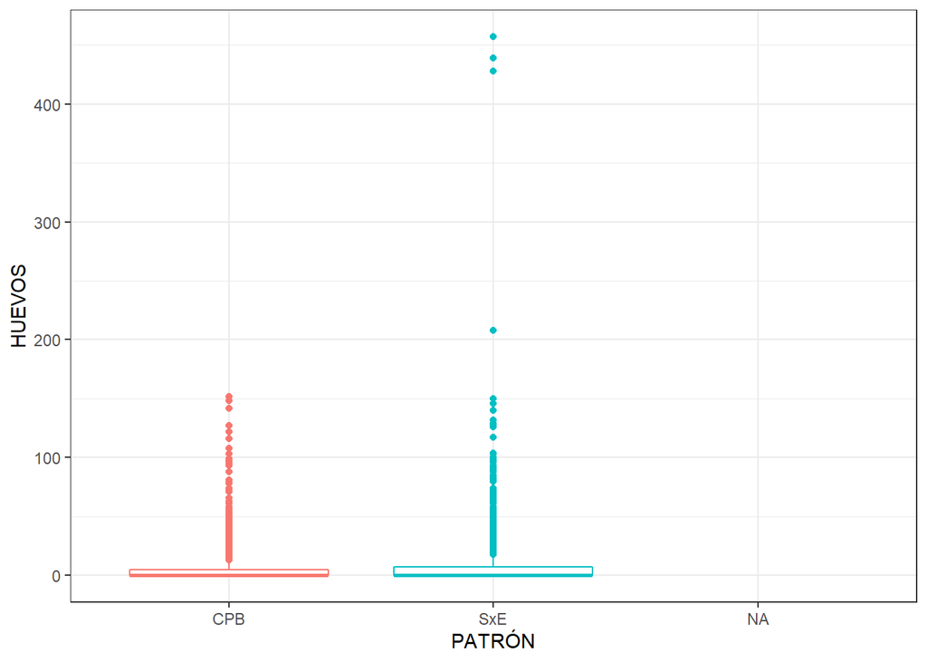

```r
#Non-parametric approach----
#Boxplot PATRÓN
ggplot(data = db_D_citri_lab, mapping = aes(x = PATRÓN, y = HUEVOS, colour = PATRÓN)) +
  geom_boxplot() +
  theme_bw() +
  theme(legend.position = "none")
```

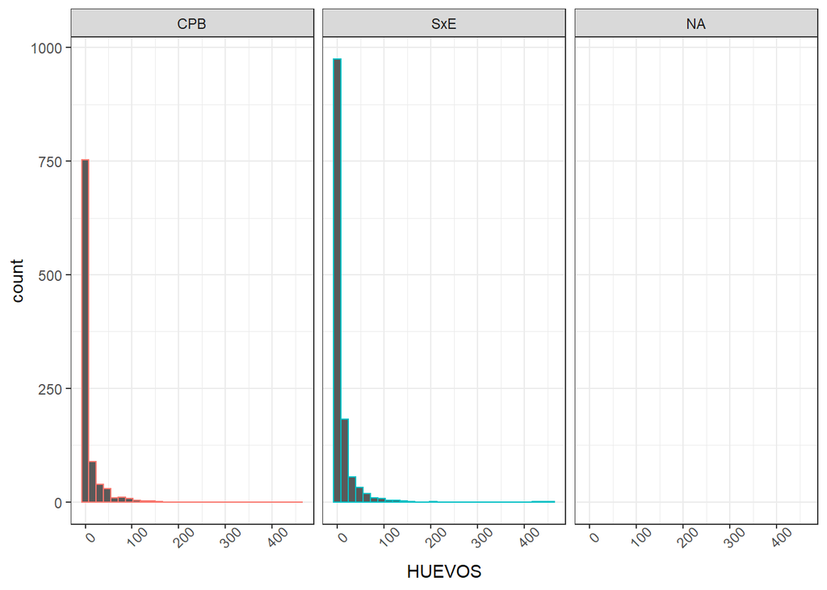

```r
#Distribution PATRÓN
ggplot(data = db_D_citri_lab, mapping = aes(x = HUEVOS, colour = PATRÓN)) +
  geom_histogram() +
  theme_bw() +
  facet_grid(. ~ PATRÓN) +
  theme(legend.position = "none")+
  theme(axis.text.x = element_text(angle = 45))
```

```r
#KW test group_1
group_1_month<- kruskal(db_D_citri_lab$HUEVOS, db_D_citri_lab$PATRÓN,group=TRUE, p.adj = "bonferroni")
group_1_month
```

```
## $statistics
##     Chisq Df    p.chisq
##   2.83338  1 0.09232385
##
## $parameters
##             test  p.ajusted                name.t ntr alpha
##   Kruskal-Wallis bonferroni db_D_citri_lab$PATRÓN   2  0.05
##
## $means
##     db_D_citri_lab.HUEVOS     rank      std    r Min Max Q25 Q50 Q75
## CPB              7.799788 1094.017 19.25421  944   0 152   0   0   5
## SxE              9.184353 1135.536 28.42649 1291   0 457   0   0   7
##
## $comparison
## NULL
##
## $groups
##     db_D_citri_lab$HUEVOS groups
## SxE              1135.536      a
## CPB              1094.017      a
##
## attr(,"class")
## [1] "group"
```

### Kruskal Wallis para la variable huevos en el factor PUNTO

Se realiza el estadístico con todos lOS PUNTOS ya que estos si presentan la misma distribución. Es de resaltar que con esta distribución los datos pueden ajustarse a un modelo Poisson o binomial negativo. El análisis se debería hacer con un Wilcoxon

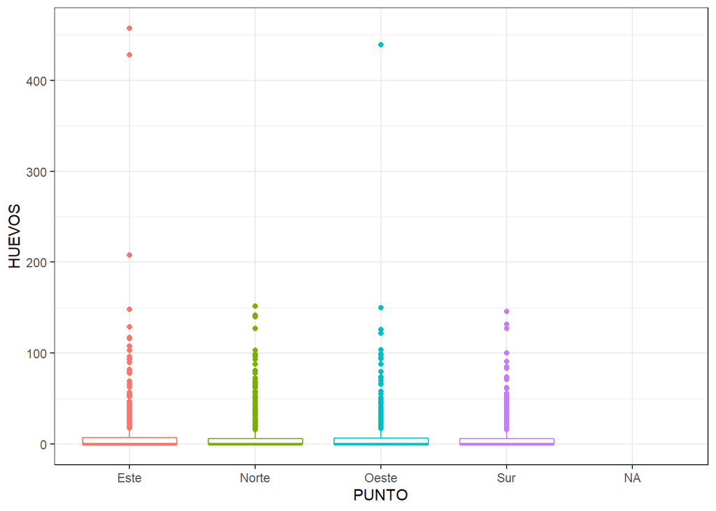

```r
#Non-parametric approach----
#Boxplot PUNTO
db_D_citri_lab$PUNTO[db_D_citri_lab$PUNTO=="Este "]<- "Este"
db_D_citri_lab$PUNTO[db_D_citri_lab$PUNTO=="Oeste "]<- "Oeste"
ggplot(data = db_D_citri_lab, mapping = aes(x = PUNTO, y = HUEVOS, colour = PUNTO)) +
  geom_boxplot() +
  theme_bw() +
  theme(legend.position = "none")
```

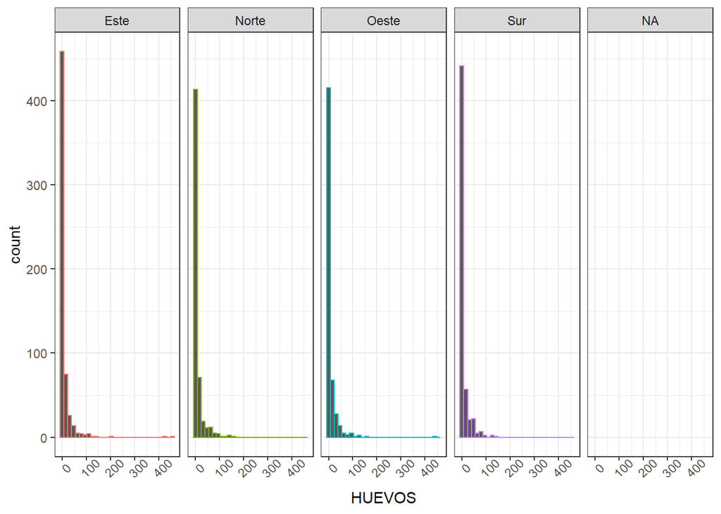

```r
#Distribution PUNTO
ggplot(data = db_D_citri_lab, mapping = aes(x = HUEVOS, colour = PUNTO)) +
  geom_histogram() +
  theme_bw() +
  facet_grid(. ~ PUNTO) +
  theme(legend.position = "none")+
  theme(axis.text.x = element_text(angle = 45))
```

```r
#KW test group_1
group_1_month<- kruskal(db_D_citri_lab$HUEVOS, db_D_citri_lab$PUNTO,group=TRUE, p.adj = "bonferroni")
group_1_month
```

```
## $statistics
##      Chisq Df   p.chisq
##   1.106529  3 0.7754981
##
## $parameters
##             test  p.ajusted               name.t ntr alpha
##   Kruskal-Wallis bonferroni db_D_citri_lab$PUNTO   4  0.05
##
## $means
##       db_D_citri_lab.HUEVOS     rank      std   r Min Max Q25 Q50  Q75
## Este               9.530303 1134.671 32.25698 594   0 457   0   0 7.00
## Norte              8.474074 1115.363 20.24904 540   0 152   0   0 6.25
## Oeste              8.650092 1121.439 26.16445 543   0 439   0   0 6.50
## Sur                7.681004 1099.459 18.12480 558   0 146   0   0 6.00
##
## $comparison
## NULL
##
## $groups
##       db_D_citri_lab$HUEVOS groups
## Este               1134.671      a
## Oeste              1121.439      a
## Norte              1115.363      a
## Sur                1099.459      a
##
## attr(,"class")
## [1] "group"
```

### Kruskal Wallis para la variable NINFAS en el factor MES

Se realiza el estadístico con todos los meses ya que estos si presentan la misma distribución. Es de resaltar que con esta distribución los datos pueden ajustarse a un modelo Poisson o binomial negativo

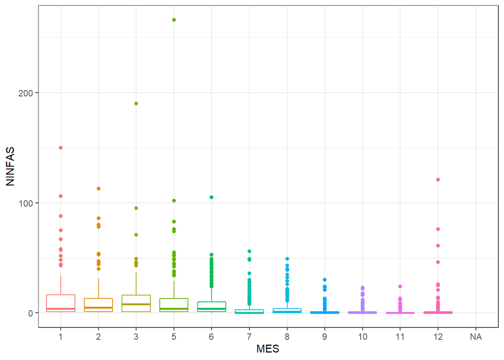

```r
#Non-parametric approach----
#Boxplot MES
ggplot(data = db_D_citri_lab, mapping = aes(x = MES, y = NINFAS, colour = MES)) +
  geom_boxplot() +
  theme_bw() +
  theme(legend.position = "none")
```

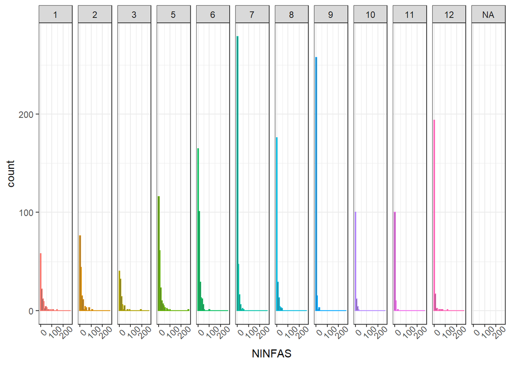

```r
#Distribution MES
ggplot(data = db_D_citri_lab, mapping = aes(x = NINFAS, colour = MES)) +
  geom_histogram() +
  theme_bw() +
  facet_grid(. ~ MES) +
  theme(legend.position = "none")+
  theme(axis.text.x = element_text(angle = 45))
```

```r
#KW test group_1
group_1_month<- kruskal(db_D_citri_lab$NINFAS, db_D_citri_lab$MES,group=TRUE, p.adj = "bonferroni")
group_1_month
```

```
## $statistics
##      Chisq Df p.chisq
##   523.1838 10       0
##
## $parameters
##             test  p.ajusted             name.t ntr alpha
##   Kruskal-Wallis bonferroni db_D_citri_lab$MES  11  0.05
##
## $means
##    db_D_citri_lab.NINFAS      rank       std   r Min Max Q25 Q50  Q75
## 1              13.991304 1465.4609 23.104073 115   0 150   1   4 16.5
## 10              1.974359  824.1368  4.520950 117   0  23   0   0  1.0
## 11              1.261261  748.8423  3.399764 111   0  24   0   0  0.5
## 12              2.694064  799.6256 11.289051 219   0 121   0   0  1.0
## 2              10.816456 1425.3386 17.431883 158   0 113   1   5 13.0
## 3              13.485149 1528.0545 23.478762 101   0 190   1   8 16.0
## 5              11.165217 1468.2500 22.624302 230   0 266   1   4 13.0
## 6               8.344512 1415.6982 11.751253 328   0 105   1   4 10.0
## 7               3.389205  987.9190  7.241004 352   0  56   0   0  3.0
## 8               4.145374 1067.4692  8.146394 227   0  49   0   1  4.0
## 9               1.129964  736.0722  3.519779 277   0  30   0   0  1.0
##
## $comparison
## NULL
##
## $groups
##    db_D_citri_lab$NINFAS groups
## 3              1528.0545      a
## 5              1468.2500      a
## 1              1465.4609      a
## 2              1425.3386      a
## 6              1415.6982      a
## 8              1067.4692      b
## 7               987.9190     bc
## 10              824.1368     cd
## 12              799.6256      d
## 11              748.8423      d
## 9               736.0722      d
##
## attr(,"class")
## [1] "group"
```

### Kruskal Wallis para la variable NINFAS en el factor CULTIVO

Se realiza el estadístico con todos los CULTIVARES ya que estos si presentan la misma distribución. Es de resaltar que con esta distribución los datos pueden ajustarse a un modelo Poisson o binomial negativo

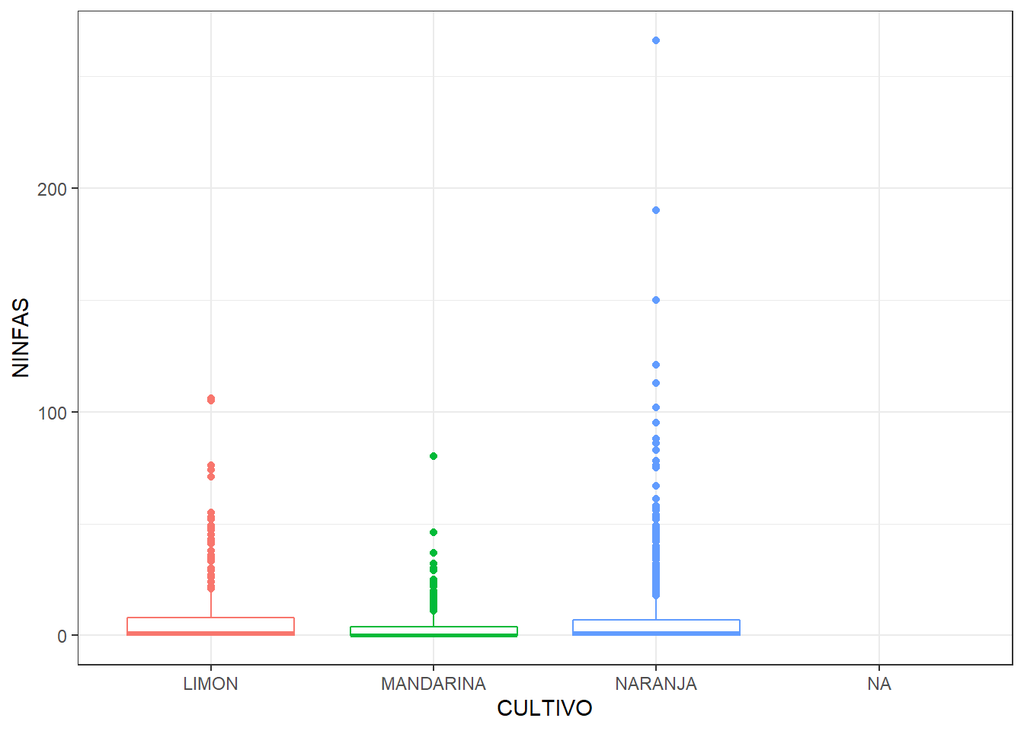

```r
#Non-parametric approach----
#Boxplot CULTIVO
ggplot(data = db_D_citri_lab, mapping = aes(x = CULTIVO, y = NINFAS, colour = CULTIVO)) +
  geom_boxplot() +
  theme_bw() +
  theme(legend.position = "none")
```

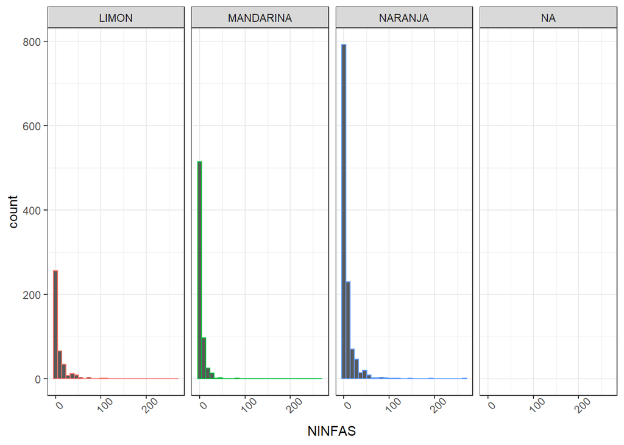

```r
#Distribution CULTIVO
ggplot(data = db_D_citri_lab, mapping = aes(x = NINFAS, colour = CULTIVO)) +
  geom_histogram() +
  theme_bw() +
  facet_grid(. ~ CULTIVO) +
  theme(legend.position = "none")+
  theme(axis.text.x = element_text(angle = 45))
```

```r
#KW test group_1
group_1_month<- kruskal(db_D_citri_lab$NINFAS, db_D_citri_lab$CULTIVO,group=TRUE, p.adj = "bonferroni")
group_1_month
```

```
## $statistics
##      Chisq Df      p.chisq
##   27.54656  2 1.043137e-06
##
## $parameters
##             test  p.ajusted                 name.t ntr alpha
##   Kruskal-Wallis bonferroni db_D_citri_lab$CULTIVO   3  0.05
##
## $means
##           db_D_citri_lab.NINFAS     rank       std    r Min Max Q25 Q50 Q75
## LIMON                  7.402564 1163.986 14.197088  390   0 106   0   1   8
## MANDARINA              3.288344 1011.744  6.703255  652   0  80   0   0   4
## NARANJA                7.009220 1161.038 16.410447 1193   0 266   0   1   7
##
## $comparison
## NULL
##
## $groups
##           db_D_citri_lab$NINFAS groups
## LIMON                  1163.986      a
## NARANJA                1161.038      a
## MANDARINA              1011.744      b
##
## attr(,"class")
## [1] "group"
```

### Kruskal Wallis para la variable NINFAS en el factor COPA

Se realiza el estadístico con todos lAS VARIEDADES ya que estos si presentan la misma distribución. Es de resaltar que con esta distribución los datos pueden ajustarse a un modelo Poisson o binomial negativo

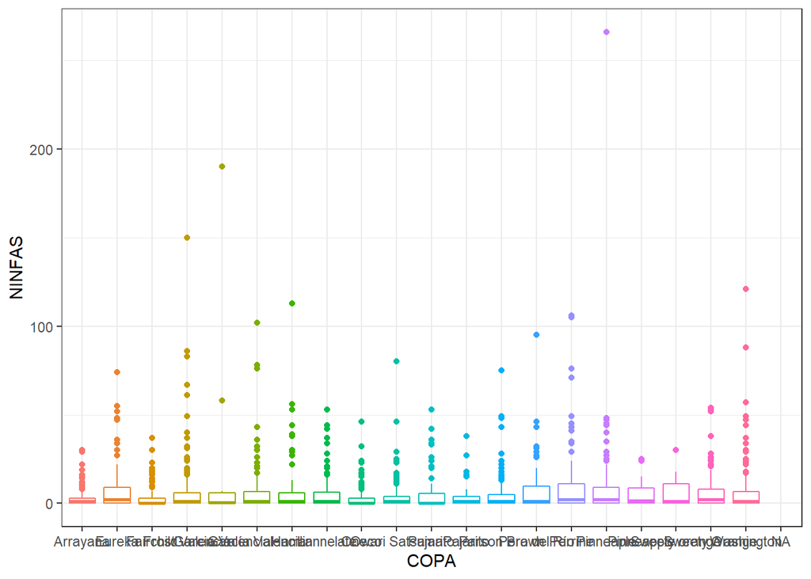

```r
#Non-parametric approach----
#Boxplot COPA
ggplot(data = db_D_citri_lab, mapping = aes(x = COPA, y = NINFAS, colour = COPA)) +
  geom_boxplot() +
  theme_bw() +
  theme(legend.position = "none")
```

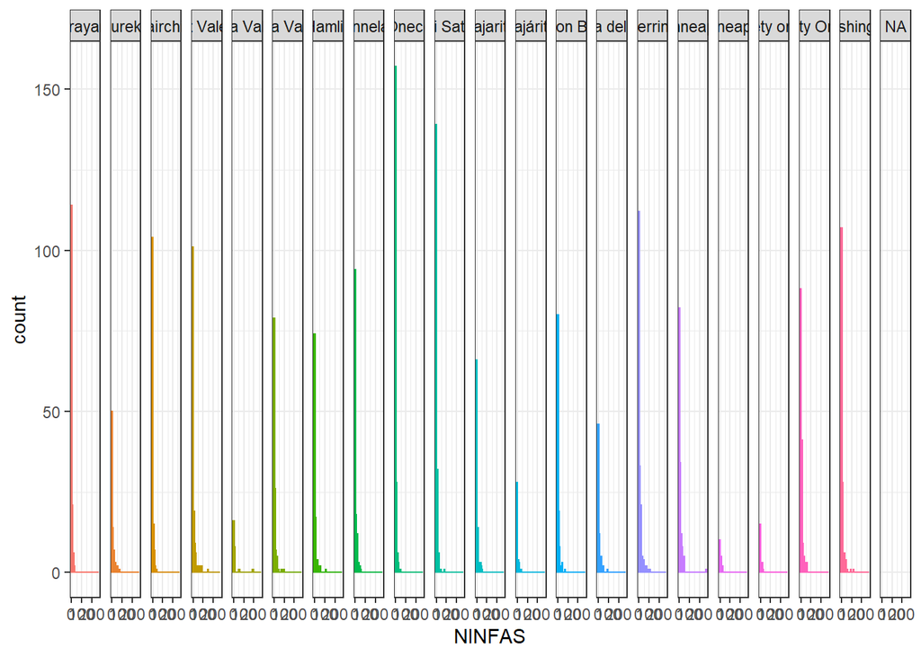

```r
#Distribution COPA
ggplot(data = db_D_citri_lab, mapping = aes(x = NINFAS, colour = COPA)) +
  geom_histogram() +
  theme_bw() +
  facet_grid(. ~ COPA) +
  theme(legend.position = "none")
```

```r
#KW test group_1
group_1_month<- kruskal(db_D_citri_lab$NINFAS, db_D_citri_lab$COPA,group=TRUE, p.adj = "bonferroni")
group_1_month
```

```
## $statistics
##      Chisq Df      p.chisq
##   58.92864 19 5.709748e-06
##
## $parameters
##             test  p.ajusted              name.t ntr alpha
##   Kruskal-Wallis bonferroni db_D_citri_lab$COPA  20  0.05
##
## $means
##                 db_D_citri_lab.NINFAS      rank       std   r Min Max Q25 Q50
## Arrayana                     2.881119 1017.6189  5.249399 143   0  30   0 1.0
## Eureka                       8.839506 1227.2037 15.046143  81   0  74   0 2.0
## Fairchild                    3.263566  980.4574  6.347390 129   0  37   0 0.0
## Frost Valencia               7.860140 1143.0524 18.802383 143   0 150   0 1.0
## Garcia Valencia             11.692308 1088.5192 38.070219  26   0 190   0 0.5
## García Valencia              6.950820 1166.9221 15.008456 122   0 102   0 1.0
## Hamlin                       6.852941 1115.5000 15.560420 102   0 113   0 1.0
## Lannelate                    5.401515 1088.9697  9.913257 132   0  53   0 1.0
## Oneco                        2.738462  928.9949  5.848456 195   0  46   0 0.0
## Owari Satsuma                4.200000 1116.2405  8.504986 185   0  80   0 1.0
## Pajarito                     5.384615 1019.7418 10.842067  91   0  53   0 0.0
## Pajárito                     4.351351 1051.0405  8.367318  37   0  38   0 1.0
## Parson Brown                 5.309735 1077.5929 11.259186 113   0  75   0 1.0
## Pera del Río                 7.714286 1197.1714 14.897858  70   0  95   0 1.0
## Perrine                      8.397790 1231.3039 16.009261 181   0 106   0 2.0
## Pinneaple                    9.186207 1246.1759 24.249280 145   0 266   0 2.0
## Pinneapple                   5.888889 1218.0000  8.115989  18   0  25   0 1.5
## Sweety orange                5.571429 1164.9048  8.316077  21   0  30   0 1.0
## Sweety Orange                6.129252 1267.2143  9.647395 147   0  54   0 2.0
## Washington                   7.000000 1133.3636 15.648091 154   0 121   0 1.0
##                   Q75
## Arrayana         3.00
## Eureka           9.00
## Fairchild        3.00
## Frost Valencia   6.00
## Garcia Valencia  6.00
## García Valencia  6.75
## Hamlin           5.75
## Lannelate        6.25
## Oneco            3.00
```

[output cut: 25 more lines]

```
## Frost Valencia              1143.0524    abc
## Washington                  1133.3636    abc
## Owari Satsuma               1116.2405    abc
## Hamlin                      1115.5000    abc
## Lannelate                   1088.9697    abc
## Garcia Valencia             1088.5192    abc
## Parson Brown                1077.5929    abc
## Pajárito                    1051.0405    abc
## Pajarito                    1019.7418    abc
## Arrayana                    1017.6189    abc
## Fairchild                    980.4574     bc
## Oneco                        928.9949      c
##
## attr(,"class")
## [1] "group"
```

### Kruskal Wallis para la variable NINFAS en el factor PATRÓN

Se realiza el estadístico con todos lOS PORTAINJERTOS ya que estos si presentan la misma distribución. Es de resaltar que con esta distribución los datos pueden ajustarse a un modelo Poisson o binomial negativo. El análisis se debería hacer con un Wilcoxon

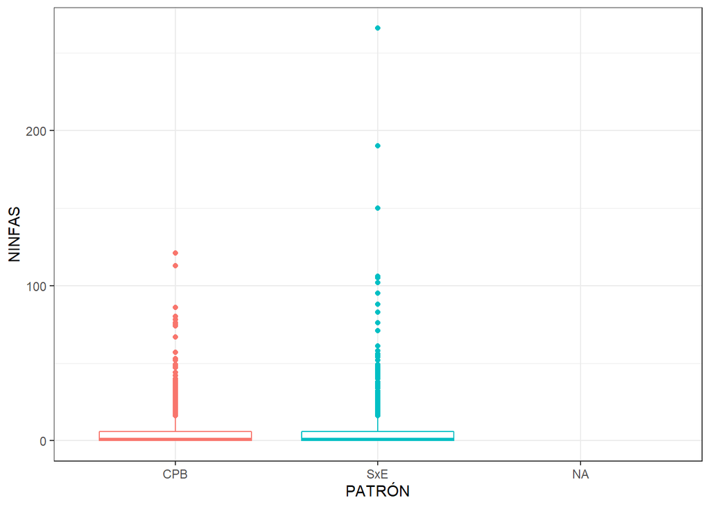

```r
#Non-parametric approach----
#Boxplot PATRÓN
ggplot(data = db_D_citri_lab, mapping = aes(x = PATRÓN, y = NINFAS, colour = PATRÓN)) +
  geom_boxplot() +
  theme_bw() +
  theme(legend.position = "none")
```

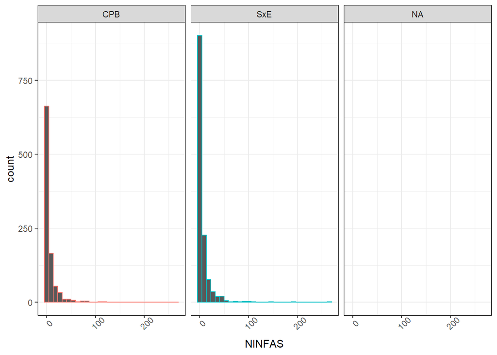

```r
#Distribution PATRÓN
ggplot(data = db_D_citri_lab, mapping = aes(x = NINFAS, colour = PATRÓN)) +
  geom_histogram() +
  theme_bw() +
  facet_grid(. ~ PATRÓN) +
  theme(legend.position = "none")+
  theme(axis.text.x = element_text(angle = 45))
```

```r
#KW test group_1
group_1_month<- kruskal(db_D_citri_lab$NINFAS, db_D_citri_lab$PATRÓN,group=TRUE, p.adj = "bonferroni")
group_1_month
```

```
## $statistics
##      Chisq Df   p.chisq
##   0.581172  1 0.4458533
##
## $parameters
##             test  p.ajusted                name.t ntr alpha
##   Kruskal-Wallis bonferroni db_D_citri_lab$PATRÓN   2  0.05
##
## $means
##     db_D_citri_lab.NINFAS     rank      std    r Min Max Q25 Q50 Q75
## CPB              5.781780 1129.585 12.09756  944   0 121   0   1   6
## SxE              6.146398 1109.529 15.18264 1291   0 266   0   1   6
##
## $comparison
## NULL
##
## $groups
##     db_D_citri_lab$NINFAS groups
## CPB              1129.585      a
## SxE              1109.529      a
##
## attr(,"class")
## [1] "group"
```

### Kruskal Wallis para la variable NINFAS en el factor PUNTO

Se realiza el estadístico con todos lOS PUNTOS ya que estos si presentan la misma distribución. Es de resaltar que con esta distribución los datos pueden ajustarse a un modelo Poisson o binomial negativo. El análisis se debería hacer con un Wilcoxon

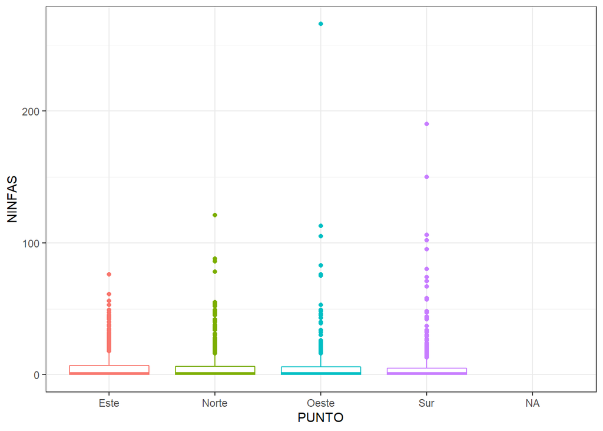

```r
#Non-parametric approach----
#Boxplot PUNTO
db_D_citri_lab$PUNTO[db_D_citri_lab$PUNTO=="Este "]<- "Este"
db_D_citri_lab$PUNTO[db_D_citri_lab$PUNTO=="Oeste "]<- "Oeste"
ggplot(data = db_D_citri_lab, mapping = aes(x = PUNTO, y = NINFAS, colour = PUNTO)) +
  geom_boxplot() +
  theme_bw() +
  theme(legend.position = "none")
```

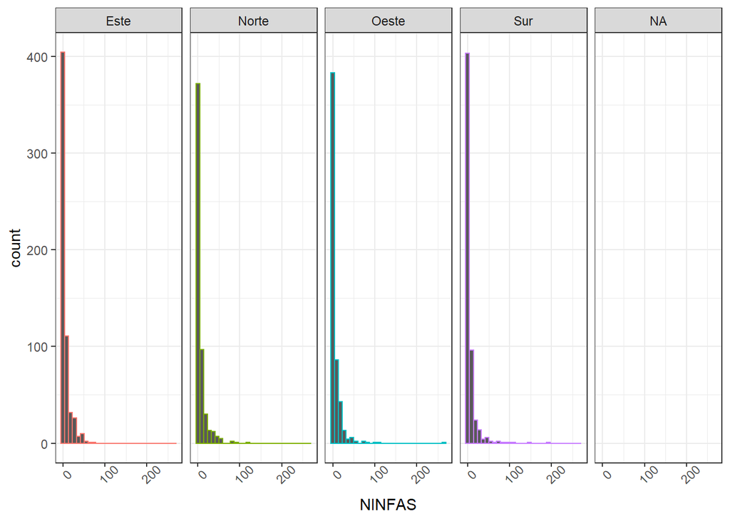

```r
#Distribution PUNTO
ggplot(data = db_D_citri_lab, mapping = aes(x = NINFAS, colour = PUNTO)) +
  geom_histogram() +
  theme_bw() +
  facet_grid(. ~ PUNTO) +
  theme(legend.position = "none")+
  theme(axis.text.x = element_text(angle = 45))
```

```r
#KW test group_1
group_1_month<- kruskal(db_D_citri_lab$NINFAS, db_D_citri_lab$PUNTO,group=TRUE, p.adj = "bonferroni")
group_1_month
```

```
## $statistics
##      Chisq Df   p.chisq
##   2.066827  3 0.5586529
##
## $parameters
##             test  p.ajusted               name.t ntr alpha
##   Kruskal-Wallis bonferroni db_D_citri_lab$PUNTO   4  0.05
##
## $means
##       db_D_citri_lab.NINFAS     rank      std   r Min Max Q25 Q50  Q75
## Este               5.723906 1137.540 10.31467 594   0  76   0   1 7.00
## Norte              6.177778 1132.419 12.69588 540   0 121   0   1 6.25
## Oeste              6.058932 1110.016 16.36169 543   0 266   0   1 6.00
## Sur                6.034050 1091.015 15.87159 558   0 190   0   1 5.00
##
## $comparison
## NULL
##
## $groups
##       db_D_citri_lab$NINFAS groups
## Este               1137.540      a
## Norte              1132.419      a
## Oeste              1110.016      a
## Sur                1091.015      a
##
## attr(,"class")
## [1] "group"
```

### Kruskal Wallis para la variable ADULTO en el factor MES

Se realiza el estadístico con todos los meses ya que estos si presentan la misma distribución. Es de resaltar que con esta distribución los datos pueden ajustarse a un modelo Poisson o binomial negativo

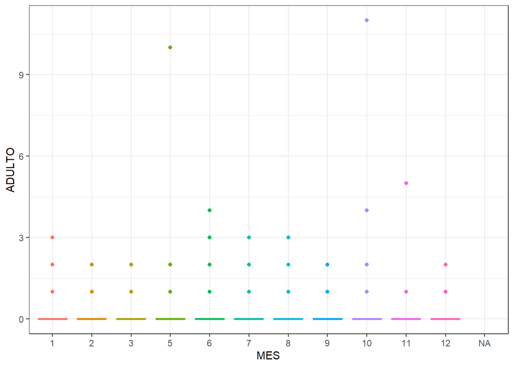

```r
#Non-parametric approach----
#Boxplot MES
ggplot(data = db_D_citri_lab, mapping = aes(x = MES, y = ADULTO, colour = MES)) +
  geom_boxplot() +
  theme_bw() +
  theme(legend.position = "none")
```

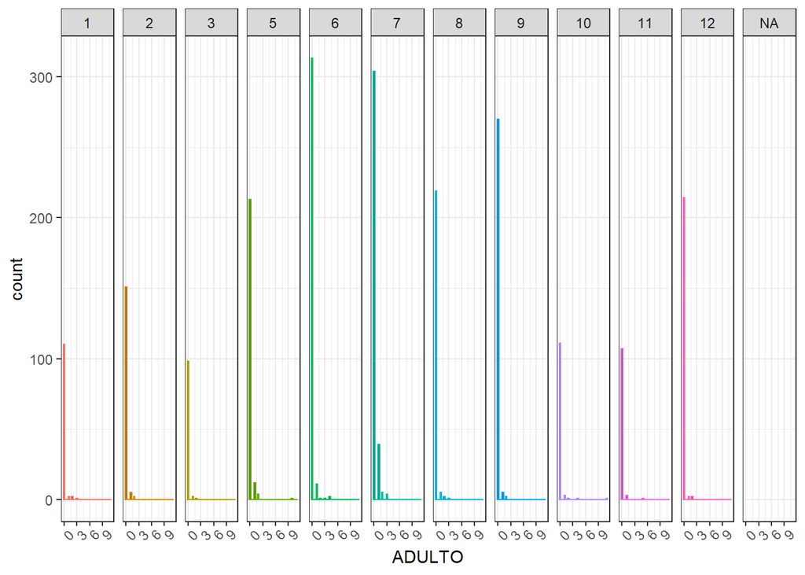

```r
#Distribution MES
ggplot(data = db_D_citri_lab, mapping = aes(x = ADULTO, colour = MES)) +
  geom_histogram() +
  theme_bw() +
  facet_grid(. ~ MES) +
  theme(legend.position = "none")+
  theme(axis.text.x = element_text(angle = 45))
```

```r
#KW test group_1
group_1_month<- kruskal(db_D_citri_lab$ADULTO, db_D_citri_lab$MES,group=TRUE, p.adj = "bonferroni")
group_1_month
```

```
## $statistics
##      Chisq Df     p.chisq
##   60.18328 10 3.34608e-09
##
## $parameters
##             test  p.ajusted             name.t ntr alpha
##   Kruskal-Wallis bonferroni db_D_citri_lab$MES  11  0.05
##
## $means
##    db_D_citri_lab.ADULTO     rank       std   r Min Max Q25 Q50 Q75
## 1             0.07826087 1104.878 0.4006098 115   0   3   0   0   0
## 10            0.17094017 1113.675 1.1008664 117   0  11   0   0   0
## 11            0.07207207 1095.815 0.4993034 111   0   5   0   0   0
## 12            0.02752294 1076.183 0.2128895 218   0   2   0   0   0
## 2             0.05696203 1104.915 0.2820234 158   0   2   0   0   0
## 3             0.03960396 1088.708 0.2416937 101   0   2   0   0   0
## 5             0.13043478 1138.072 0.7361144 230   0  10   0   0   0
## 6             0.07317073 1106.622 0.4072880 328   0   4   0   0   0
## 7             0.17329545 1207.016 0.4904471 352   0   3   0   0   0
## 8             0.05286344 1095.046 0.3074707 227   0   3   0   0   0
## 9             0.03249097 1083.686 0.2145739 277   0   2   0   0   0
##
## $comparison
## NULL
##
## $groups
##    db_D_citri_lab$ADULTO groups
## 7               1207.016      a
## 5               1138.072     ab
## 10              1113.675      b
## 6               1106.622      b
## 2               1104.915      b
## 1               1104.878      b
## 11              1095.815      b
## 8               1095.046      b
## 3               1088.708      b
## 9               1083.686      b
## 12              1076.183      b
##
## attr(,"class")
## [1] "group"
```

### Kruskal Wallis para la variable ADULTO en el factor CULTIVO

Se realiza el estadístico con todos los CULTIVARES ya que estos si presentan la misma distribución. Es de resaltar que con esta distribución los datos pueden ajustarse a un modelo Poisson o binomial negativo

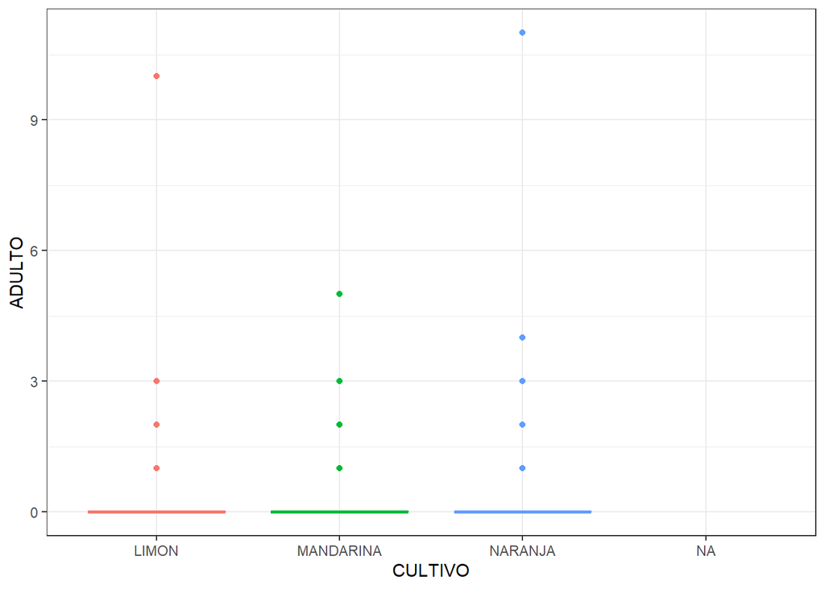

```r
#Non-parametric approach----
#Boxplot CULTIVO
ggplot(data = db_D_citri_lab, mapping = aes(x = CULTIVO, y = ADULTO, colour = CULTIVO)) +
  geom_boxplot() +
  theme_bw() +
  theme(legend.position = "none")
```

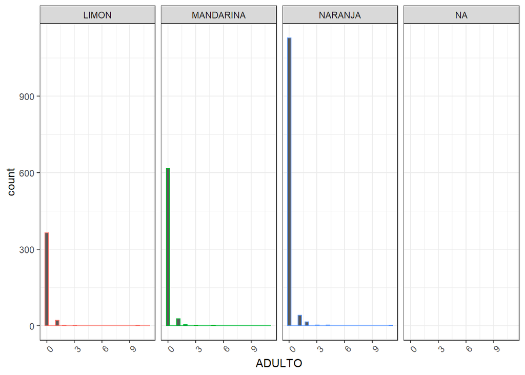

```r
#Distribution CULTIVO
ggplot(data = db_D_citri_lab, mapping = aes(x = ADULTO, colour = CULTIVO)) +
  geom_histogram() +
  theme_bw() +
  facet_grid(. ~ CULTIVO) +
  theme(legend.position = "none")+
  theme(axis.text.x = element_text(angle = 45))
```

```r
#KW test group_1
group_1_month<- kruskal(db_D_citri_lab$ADULTO, db_D_citri_lab$CULTIVO,group=TRUE, p.adj = "bonferroni")
group_1_month
```

```
## $statistics
##      Chisq Df   p.chisq
##   0.609506  2 0.7373055
##
## $parameters
##             test  p.ajusted                 name.t ntr alpha
##   Kruskal-Wallis bonferroni db_D_citri_lab$CULTIVO   3  0.05
##
## $means
##           db_D_citri_lab.ADULTO     rank       std    r Min Max Q25 Q50 Q75
## LIMON                0.10000000 1126.682 0.5979829  390   0  10   0   0   0
## MANDARINA            0.07361963 1115.281 0.3644457  652   0   5   0   0   0
## NARANJA              0.08808725 1115.710 0.4949373 1192   0  11   0   0   0
##
## $comparison
## NULL
##
## $groups
##           db_D_citri_lab$ADULTO groups
## LIMON                  1126.682      a
## NARANJA                1115.710      a
## MANDARINA              1115.281      a
##
## attr(,"class")
## [1] "group"
```

### Kruskal Wallis para la variable ADULTO en el factor COPA

Se realiza el estadístico con todos lAS VARIEDADES ya que estos si presentan la misma distribución. Es de resaltar que con esta distribución los datos pueden ajustarse a un modelo Poisson o binomial negativo

[figure not shown]

```r
#Non-parametric approach----
#Boxplot COPA
ggplot(data = db_D_citri_lab, mapping = aes(x = COPA, y = ADULTO, colour = COPA)) +
  geom_boxplot() +
  theme_bw() +
  theme(legend.position = "none")
```

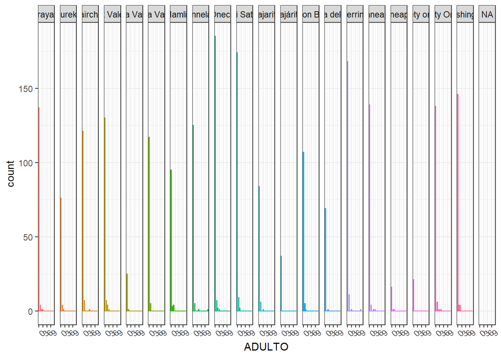

```r
#Distribution COPA
ggplot(data = db_D_citri_lab, mapping = aes(x = ADULTO, colour = COPA)) +
  geom_histogram() +
  theme_bw() +
  facet_grid(. ~ COPA) +
  theme(legend.position = "none")+
  theme(axis.text.x = element_text(angle = 45))
```

```r
#KW test group_1
group_1_month<- kruskal(db_D_citri_lab$ADULTO, db_D_citri_lab$COPA,group=TRUE, p.adj = "bonferroni")
group_1_month
```

```
## $statistics
##      Chisq Df   p.chisq
##   13.21074 19 0.8276098
##
## $parameters
##             test  p.ajusted              name.t ntr alpha
##   Kruskal-Wallis bonferroni db_D_citri_lab$COPA  20  0.05
##
## $means
##                 db_D_citri_lab.ADULTO     rank       std   r Min Max Q25 Q50
## Arrayana                   0.06293706 1102.510 0.3401902 143   0   3   0   0
## Eureka                     0.07407407 1124.056 0.3073181  81   0   2   0   0
## Fairchild                  0.09302326 1124.283 0.4912017 129   0   5   0   0
## Frost Valencia             0.12676056 1150.472 0.4590949 142   0   3   0   0
## Garcia Valencia            0.03846154 1097.788 0.1961161  26   0   1   0   0
## García Valencia            0.04098361 1100.561 0.1990698 122   0   1   0   0
## Hamlin                     0.10784314 1133.132 0.4199685 102   0   2   0   0
## Lannelate                  0.15151515 1114.973 1.0299696 132   0  11   0   0
## Oneco                      0.07179487 1112.813 0.3442822 195   0   3   0   0
## Owari Satsuma              0.07027027 1121.476 0.2956798 185   0   2   0   0
## Pajarito                   0.09890110 1140.846 0.3959502  91   0   3   0   0
## Pajárito                   0.00000000 1055.500 0.0000000  37   0   0   0   0
## Parson Brown               0.06194690 1114.372 0.2765601 113   0   2   0   0
## Pera del Río               0.02857143 1072.000 0.2390457  70   0   2   0   0
## Perrine                    0.13259669 1135.287 0.8055974 181   0  10   0   0
## Pinneaple                  0.07586207 1101.997 0.4422600 145   0   4   0   0
## Pinneapple                 0.16666667 1180.750 0.5144958  18   0   2   0   0
## Sweety orange              0.00000000 1055.500 0.0000000  21   0   0   0   0
## Sweety Orange              0.10204082 1124.180 0.4787926 147   0   4   0   0
## Washington                 0.07792208 1114.058 0.3529978 154   0   2   0   0
##                 Q75
## Arrayana          0
## Eureka            0
## Fairchild         0
## Frost Valencia    0
## Garcia Valencia   0
## García Valencia   0
## Hamlin            0
## Lannelate         0
## Oneco             0
```

[output cut: 25 more lines]

```
## Owari Satsuma                1121.476      a
## Lannelate                    1114.973      a
## Parson Brown                 1114.372      a
## Washington                   1114.058      a
## Oneco                        1112.813      a
## Arrayana                     1102.510      a
## Pinneaple                    1101.997      a
## García Valencia              1100.561      a
## Garcia Valencia              1097.788      a
## Pera del Río                 1072.000      a
## Pajárito                     1055.500      a
## Sweety orange                1055.500      a
##
## attr(,"class")
## [1] "group"
```

### Kruskal Wallis para la variable ADULTO en el factor PATRÓN

Se realiza el estadístico con todos lOS PORTAINJERTOS ya que estos si presentan la misma distribución. Es de resaltar que con esta distribución los datos pueden ajustarse a un modelo Poisson o binomial negativo. El análisis se debería hacer con un Wilcoxon

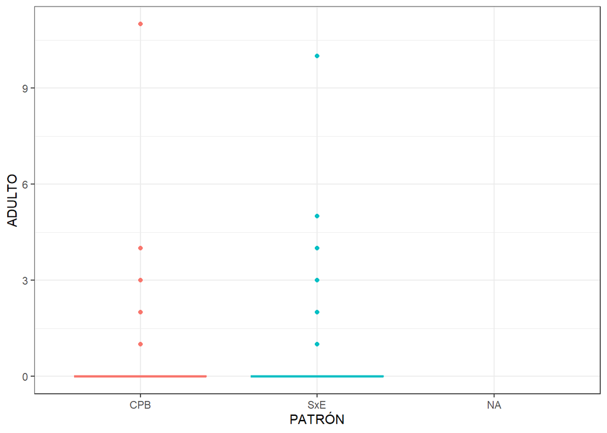

```r
#Non-parametric approach----
#Boxplot PATRÓN
ggplot(data = db_D_citri_lab, mapping = aes(x = PATRÓN, y = ADULTO, colour = PATRÓN)) +
  geom_boxplot() +
  theme_bw() +
  theme(legend.position = "none")
```

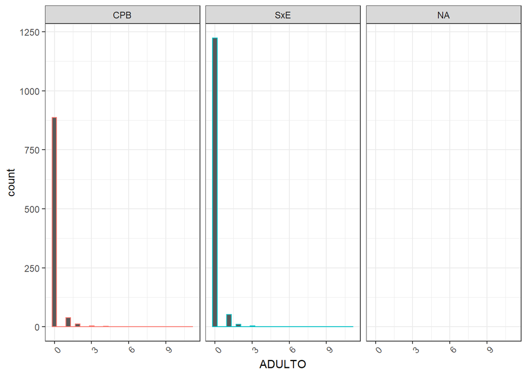

```r
#Distribution PATRÓN
ggplot(data = db_D_citri_lab, mapping = aes(x = ADULTO, colour = PATRÓN)) +
  geom_histogram() +
  theme_bw() +
  facet_grid(. ~ PATRÓN) +
  theme(legend.position = "none")+
  theme(axis.text.x = element_text(angle = 45))
```

```r
#KW test group_1
group_1_month<- kruskal(db_D_citri_lab$ADULTO, db_D_citri_lab$PATRÓN,group=TRUE, p.adj = "bonferroni")
group_1_month
```

```
## $statistics
##     Chisq Df   p.chisq
##   0.79244  1 0.3733633
##
## $parameters
##             test  p.ajusted                name.t ntr alpha
##   Kruskal-Wallis bonferroni db_D_citri_lab$PATRÓN   2  0.05
##
## $means
##     db_D_citri_lab.ADULTO     rank       std    r Min Max Q25 Q50 Q75
## CPB            0.09851695 1123.134 0.5309488  944   0  11   0   0   0
## SxE            0.07674419 1113.377 0.4416296 1290   0  10   0   0   0
##
## $comparison
## NULL
##
## $groups
##     db_D_citri_lab$ADULTO groups
## CPB              1123.134      a
## SxE              1113.377      a
##
## attr(,"class")
## [1] "group"
```

### Kruskal Wallis para la variable ADULTO en el factor PUNTO

Se realiza el estadístico con todos lOS PUNTOS ya que estos si presentan la misma distribución. Es de resaltar que con esta distribución los datos pueden ajustarse a un modelo Poisson o binomial negativo. El análisis se debería hacer con un Wilcoxon

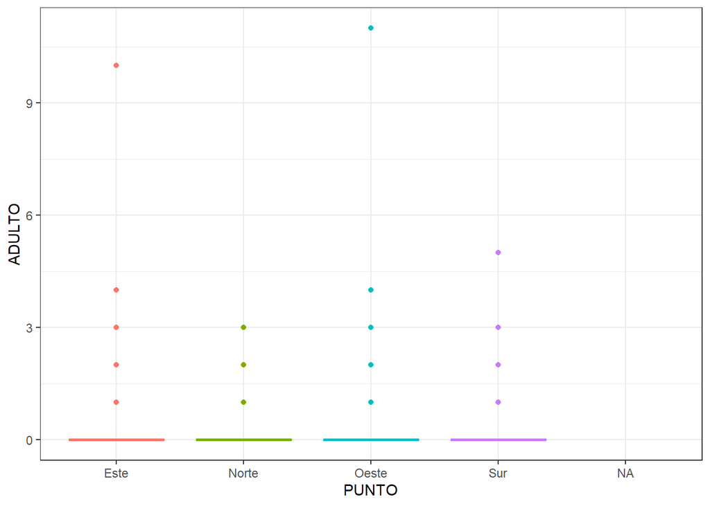

```r
#Non-parametric approach----
#Boxplot PUNTO
db_D_citri_lab$PUNTO[db_D_citri_lab$PUNTO=="Este "]<- "Este"
db_D_citri_lab$PUNTO[db_D_citri_lab$PUNTO=="Oeste "]<- "Oeste"
ggplot(data = db_D_citri_lab, mapping = aes(x = PUNTO, y = ADULTO, colour = PUNTO)) +
  geom_boxplot() +
  theme_bw() +
  theme(legend.position = "none")
```

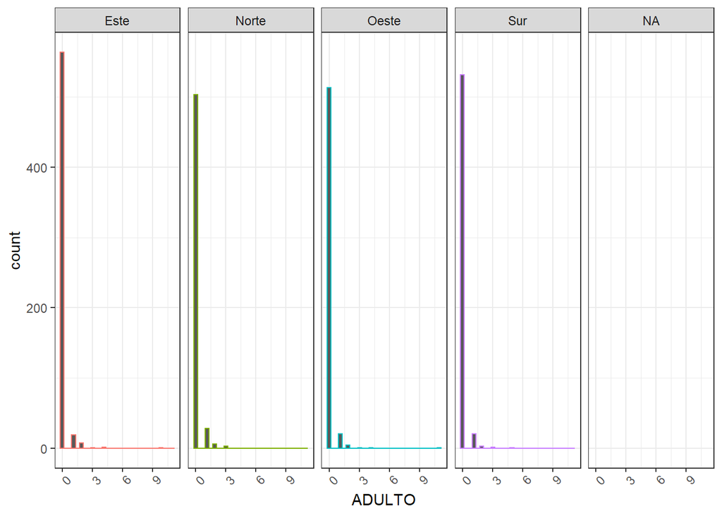

```r
#Distribution PUNTO
ggplot(data = db_D_citri_lab, mapping = aes(x = ADULTO, colour = PUNTO)) +
  geom_histogram() +
  theme_bw() +
  facet_grid(. ~ PUNTO) +
  theme(legend.position = "none")+
  theme(axis.text.x = element_text(angle = 45))
```

```r
#KW test group_1
group_1_month<- kruskal(db_D_citri_lab$ADULTO, db_D_citri_lab$PUNTO,group=TRUE, p.adj = "bonferroni")
group_1_month
```

```
## $statistics
##      Chisq Df   p.chisq
##   2.401462  3 0.4933625
##
## $parameters
##             test  p.ajusted               name.t ntr alpha
##   Kruskal-Wallis bonferroni db_D_citri_lab$PUNTO   4  0.05
##
## $means
##       db_D_citri_lab.ADULTO     rank       std   r Min Max Q25 Q50 Q75
## Este             0.09427609 1114.130 0.5611367 594   0  10   0   0   0
## Norte            0.09074074 1131.842 0.3719120 540   0   3   0   0   0
## Oeste            0.09040590 1115.255 0.5809198 542   0  11   0   0   0
## Sur              0.06810036 1109.389 0.3630417 558   0   5   0   0   0
##
## $comparison
## NULL
##
## $groups
##       db_D_citri_lab$ADULTO groups
## Norte              1131.842      a
## Oeste              1115.255      a
## Este               1114.130      a
## Sur                1109.389      a
##
## attr(,"class")
## [1] "group"
```

#### Se adjunta los gráficos en Power Point